# What is Encoding in Machine Learning?

In machine learning, **encoding** is the process of converting categorical data (non-numeric data) into a numerical format that machine learning algorithms can process. Many machine learning models work only with numerical data, and encoding allows us to transform text labels or categories into numbers without altering the underlying meaning or relationships between them.

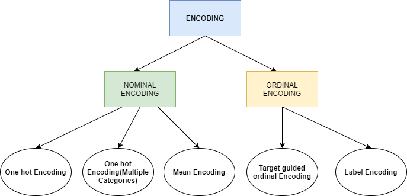

```python
# Feature Engineering
          |
feature Transformatin
          |
1.) feature scalling
2.) Encoding Categorical data

            Data

 numerical       categorical Data

                    Ordinal
                    Nominal
```

### Types of Encoding

1. **Label Encoding**
2. **Ordinal Encoding**
3. **One-Hot Encoding**
4. **Binary Encoding**
5. **Frequency Encoding**
6. **Hash Encoding**
7. **Target Encoding**

### 1. **Label Encoding**

Label Encoding assigns a unique integer to each category. It is used when the categorical variable is **ordinal** (i.e., it has a meaningful order).

- **Explanation**: Each category is converted into a number.
  - E.g., for a "Size" feature: `Small -> 1`, `Medium -> 2`, `Large -> 3`.
- **Code Example**:

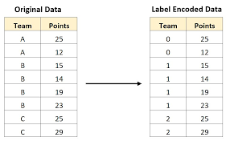

```python
import pandas as pd
```

```python
df=pd.read_csv("synthetic_customer_data.csv")
df
```

|  | age | gender | review | education | purchased | job_role | marital_status | city |
| --- | --- | --- | --- | --- | --- | --- | --- | --- |
| 0 | 56 | Female | Good | School | No | Artist | Married | New York |
| 1 | 69 | Female | Average | UG | No | Lawyer | Divorced | Chicago |
| 2 | 46 | Male | Good | School | Yes | Artist | Married | San Francisco |
| 3 | 32 | Female | Average | School | No | Manager | Single | Houston |
| 4 | 60 | Female | Good | UG | No | Artist | Single | Phoenix |
| ... | ... | ... | ... | ... | ... | ... | ... | ... |
| 995 | 18 | Female | Good | UG | No | Clerk | Single | Phoenix |
| 996 | 35 | Male | Poor | PG | No | Clerk | Single | Los Angeles |
| 997 | 49 | Male | Poor | PG | Yes | Engineer | Divorced | Phoenix |
| 998 | 64 | Female | Poor | School | No | Scientist | Divorced | San Francisco |
| 999 | 66 | Male | Poor | PG | Yes | Artist | Married | Chicago |

1000 rows × 8 columns

```python
df['purchased'].map({'Yes':1,'No':0})
```

```
0      0
1      0
2      1
3      0
4      0
      ..
995    0
996    0
997    1
998    0
999    1
Name: purchased, Length: 1000, dtype: int64
```

```python
from sklearn.preprocessing import LabelEncoder
```

```python
encoder1=LabelEncoder()
```

```python
x= encoder1.fit_transform(df['purchased'])
```

```python
df['purchased']=x
df
```

|  | age | gender | review | education | purchased | job_role | marital_status | city |
| --- | --- | --- | --- | --- | --- | --- | --- | --- |
| 0 | 56 | Female | Good | School | 0 | Artist | Married | New York |
| 1 | 69 | Female | Average | UG | 0 | Lawyer | Divorced | Chicago |
| 2 | 46 | Male | Good | School | 1 | Artist | Married | San Francisco |
| 3 | 32 | Female | Average | School | 0 | Manager | Single | Houston |
| 4 | 60 | Female | Good | UG | 0 | Artist | Single | Phoenix |
| ... | ... | ... | ... | ... | ... | ... | ... | ... |
| 995 | 18 | Female | Good | UG | 0 | Clerk | Single | Phoenix |
| 996 | 35 | Male | Poor | PG | 0 | Clerk | Single | Los Angeles |
| 997 | 49 | Male | Poor | PG | 1 | Engineer | Divorced | Phoenix |
| 998 | 64 | Female | Poor | School | 0 | Scientist | Divorced | San Francisco |
| 999 | 66 | Male | Poor | PG | 1 | Artist | Married | Chicago |

1000 rows × 8 columns

### 2. **Ordinal Encoding**

Ordinal Encoding is similar to Label Encoding, but the categories are encoded based on their order. It’s specifically used when the data has a **rank** or **order**.

- **Explanation**: Categories are replaced with integers, preserving order.
  - E.g., for "Education" level: `High School -> 1`, `Bachelor's -> 2`, `Master's -> 3`, `Ph.D. -> 4`.
- **Code Example**:

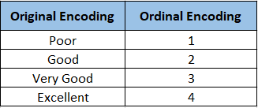

```python
from sklearn.preprocessing import OrdinalEncoder
```

```python
data=df[['review','education']]
for i in data:
    print(i, ":",data[i].unique())
```

```
review : ['Good' 'Average' 'Poor']
education : ['School' 'UG' 'PG']
```

```python
encoder2=OrdinalEncoder(categories=[['Poor', 'Average' ,'Good'],['School' ,'UG', 'PG']],dtype='int')
```

```python
encoded_data=encoder2.fit_transform(data)
encoded_data
```

```
array([[2, 0],
       [1, 1],
       [2, 0],
       ...,
       [0, 2],
       [0, 0],
       [0, 2]])
```

```python
data
```

|  | review | education |
| --- | --- | --- |
| 0 | Good | School |
| 1 | Average | UG |
| 2 | Good | School |
| 3 | Average | School |
| 4 | Good | UG |
| ... | ... | ... |
| 995 | Good | UG |
| 996 | Poor | PG |
| 997 | Poor | PG |
| 998 | Poor | School |
| 999 | Poor | PG |

1000 rows × 2 columns

```python
df[['review','education']]=encoded_data
df
```

[output not shown]

1000 rows × 8 columns

#### 3. **One-Hot Encoding**

One-Hot Encoding converts categories into binary vectors where only one value is "1" and others are "0". It is useful when the categorical feature is **nominal** (i.e., no order).

- **Explanation**: Each category gets its own binary column.
  - E.g., for a "Color" feature: `Red -> [1, 0, 0]`, `Green -> [0, 1, 0]`, `Blue -> [0, 0, 1]`.
- **Code Example**:

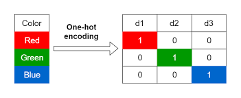

# One-Hot Encoding using pandas

```python
import pandas as pd
```

```python
data={'color':['red','blue','yellow','white','black']}
df=pd.DataFrame(data)
```

```python
df
```

|  | color |
| --- | --- |
| 0 | red |
| 1 | blue |
| 2 | yellow |
| 3 | white |
| 4 | black |

```python
pd.get_dummies(df,dtype='int')
```

|  | color_black | color_blue | color_red | color_white | color_yellow |
| --- | --- | --- | --- | --- | --- |
| 0 | 0 | 0 | 1 | 0 | 0 |
| 1 | 0 | 1 | 0 | 0 | 0 |
| 2 | 0 | 0 | 0 | 0 | 1 |
| 3 | 0 | 0 | 0 | 1 | 0 |
| 4 | 1 | 0 | 0 | 0 | 0 |

```python
pd.get_dummies(df,drop_first=True,dtype='int')
```

|  | color_blue | color_red | color_white | color_yellow |
| --- | --- | --- | --- | --- |
| 0 | 0 | 1 | 0 | 0 |
| 1 | 1 | 0 | 0 | 0 |
| 2 | 0 | 0 | 0 | 1 |
| 3 | 0 | 0 | 1 | 0 |
| 4 | 0 | 0 | 0 | 0 |

```python
df1=df[['gender','marital_status']]
df1
```

[output not shown]

1000 rows × 2 columns

```python
for i in df1:
    print(i, df1[i].unique())
```

```
gender ['Female' 'Male']
marital_status ['Married' 'Divorced' 'Single' 'Widowed']
```

```python
pd.get_dummies(df1,dtype='int',drop_first=True)
```

|  | gender_Male | marital_status_Married | marital_status_Single | marital_status_Widowed |
| --- | --- | --- | --- | --- |
| 0 | 0 | 1 | 0 | 0 |
| 1 | 0 | 0 | 0 | 0 |
| 2 | 1 | 1 | 0 | 0 |
| 3 | 0 | 0 | 1 | 0 |
| 4 | 0 | 0 | 1 | 0 |
| ... | ... | ... | ... | ... |
| 995 | 0 | 0 | 1 | 0 |
| 996 | 1 | 0 | 1 | 0 |
| 997 | 1 | 0 | 0 | 0 |
| 998 | 0 | 0 | 0 | 0 |
| 999 | 1 | 1 | 0 | 0 |

1000 rows × 4 columns

```python
from sklearn.preprocessing import OneHotEncoder
encoder1=OneHotEncoder(dtype='int')
```

```python
one_hot_encoded=encoder1.fit_transform(df1).toarray()
one_hot_encoded
```

```
array([[1, 0, 0, 1, 0, 0],
       [1, 0, 1, 0, 0, 0],
       [0, 1, 0, 1, 0, 0],
       ...,
       [0, 1, 1, 0, 0, 0],
       [1, 0, 1, 0, 0, 0],
       [0, 1, 0, 1, 0, 0]])
```

```python
pd.DataFrame(one_hot_encoded,columns=encoder1.get_feature_names_out(df1.columns),)
```

|  | gender_Female | gender_Male | marital_status_Divorced | marital_status_Married | marital_status_Single | marital_status_Widowed |
| --- | --- | --- | --- | --- | --- | --- |
| 0 | 1 | 0 | 0 | 1 | 0 | 0 |
| 1 | 1 | 0 | 1 | 0 | 0 | 0 |
| 2 | 0 | 1 | 0 | 1 | 0 | 0 |
| 3 | 1 | 0 | 0 | 0 | 1 | 0 |
| 4 | 1 | 0 | 0 | 0 | 1 | 0 |
| ... | ... | ... | ... | ... | ... | ... |
| 995 | 1 | 0 | 0 | 0 | 1 | 0 |
| 996 | 0 | 1 | 0 | 0 | 1 | 0 |
| 997 | 0 | 1 | 1 | 0 | 0 | 0 |
| 998 | 1 | 0 | 1 | 0 | 0 | 0 |
| 999 | 0 | 1 | 0 | 1 | 0 | 0 |

1000 rows × 6 columns

```python
encoder2=OneHotEncoder(drop="first",dtype='int',sparse=False)
encoded_df1=encoder2.fit_transform(df1)
pd.DataFrame(encoded_df1,columns=encoder2.get_feature_names_out(df1.columns))
```

|  | gender_Male | marital_status_Married | marital_status_Single | marital_status_Widowed |
| --- | --- | --- | --- | --- |
| 0 | 0 | 1 | 0 | 0 |
| 1 | 0 | 0 | 0 | 0 |
| 2 | 1 | 1 | 0 | 0 |
| 3 | 0 | 0 | 1 | 0 |
| 4 | 0 | 0 | 1 | 0 |
| ... | ... | ... | ... | ... |
| 995 | 0 | 0 | 1 | 0 |
| 996 | 1 | 0 | 1 | 0 |
| 997 | 1 | 0 | 0 | 0 |
| 998 | 0 | 0 | 0 | 0 |
| 999 | 1 | 1 | 0 | 0 |

1000 rows × 4 columns

### OneHot Encoding with Top Categories

```python
df2=df[['job_role','city']]
for i in df2:
    print(i , df2[i].unique())
```

```
job_role ['Artist' 'Lawyer' 'Manager' 'Teacher' 'Doctor' 'Scientist' 'Clerk'
 'Engineer']
city ['New York' 'Chicago' 'San Francisco' 'Houston' 'Phoenix' 'San Diego'
 'Los Angeles' 'Dallas']
```

```python
df2
```

|  | job_role | city |
| --- | --- | --- |
| 0 | Artist | New York |
| 1 | Lawyer | Chicago |
| 2 | Artist | San Francisco |
| 3 | Manager | Houston |
| 4 | Artist | Phoenix |
| ... | ... | ... |
| 995 | Clerk | Phoenix |
| 996 | Clerk | Los Angeles |
| 997 | Engineer | Phoenix |
| 998 | Scientist | San Francisco |
| 999 | Artist | Chicago |

1000 rows × 2 columns

```python
x=df2['job_role'].value_counts()
x
```

```
job_role
Engineer     141
Artist       137
Lawyer       124
Manager      123
Clerk        123
Scientist    122
Doctor       121
Teacher      109
Name: count, dtype: int64
```

```python
# df['job_role'].map({'Artist':'other','Clerk':'other','Teacher':'other'})
```

[output not shown]

```python
threshold=123
repl=x[x<=threshold].index
repl
```

```
Index(['Manager', 'Clerk', 'Scientist', 'Doctor', 'Teacher'], dtype='object', name='job_role')
```

```python
pd.get_dummies(df['job_role'].replace(repl,'Other'),dtype='int',drop_first=True)
```

|  | Engineer | Lawyer | Other |
| --- | --- | --- | --- |
| 0 | 0 | 0 | 0 |
| 1 | 0 | 1 | 0 |
| 2 | 0 | 0 | 0 |
| 3 | 0 | 0 | 1 |
| 4 | 0 | 0 | 0 |
| ... | ... | ... | ... |
| 995 | 0 | 0 | 1 |
| 996 | 0 | 0 | 1 |
| 997 | 1 | 0 | 0 |
| 998 | 0 | 0 | 1 |
| 999 | 0 | 0 | 0 |

1000 rows × 3 columns

```python
df2['job_role'].replace(repl,'other')
```

```
0        Artist
1        Lawyer
2        Artist
3         other
4        Artist
         ...
995       other
996       other
997    Engineer
998       other
999      Artist
Name: job_role, Length: 1000, dtype: object
```

#### 4. **Binary Encoding**

Binary Encoding converts categories into binary format. It combines aspects of One-Hot Encoding and Label Encoding, reducing dimensionality in some cases.

- **Explanation**: Categories are first Label Encoded, then converted to binary.
  - E.g., for categories `A, B, C`, binary representation could be `A -> 00, B -> 01, C -> 10`.
- **Code Example**:

```python
import category_encoders as ce

data = ['A', 'B', 'C', 'A']
encoder = ce.BinaryEncoder()
binary_encoded = encoder.fit_transform(data)
print(binary_encoded)
```

```
   0_0  0_1
0    0    1
1    1    0
2    1    1
3    0    1
```

#### 5. **Frequency Encoding**

Frequency Encoding encodes the categories based on the frequency of occurrences in the data.

- **Explanation**: It replaces each category with its frequency.
  - E.g., for data: `['A', 'B', 'B', 'C', 'A', 'A']`, `A -> 3`, `B -> 2`, `C -> 1`.
- **Code Example**:

```python
import pandas as pd

data = pd.Series(['A', 'A','B', 'B', 'C', 'A', 'A'])
frequency_encoded = data.map(data.value_counts())
print(frequency_encoded)
```

```
0    4
1    4
2    2
3    2
4    1
5    4
6    4
dtype: int64
```

#### 6. **Hash Encoding**

Hash Encoding (or Hashing Trick) transforms categories into a fixed number of columns using a hash function. It’s useful when dealing with a large number of categories.

- **Explanation**: A hash function maps categories to columns, reducing dimensionality.
  - E.g., for categories `['dog', 'cat', 'bird']`, hashing could produce fixed-length binary vectors.
- **Code Example**:

```python
import category_encoders as ce

data = ['dog', 'cat', 'bird']
encoder = ce.HashingEncoder(n_components=3)
hash_encoded = encoder.fit_transform(data)
print(hash_encoded)
```

```
   col_0  col_1  col_2
0      0      0      1
1      0      0      1
2      0      1      0
```

#### 7. **Target Encoding**

Target Encoding uses the mean of the target variable for each category to encode them. It is useful for handling high-cardinality categorical features.

- **Explanation**: Categories are replaced with the mean of the target variable.
  - E.g., for category `A` with average target 0.5, category `B` with average target 0.8, the values would be replaced accordingly.
- **Code Example**:

```python
import category_encoders as ce
import pandas as pd

df = pd.DataFrame({'feature': ['A', 'B', 'A', 'B'], 'target': [1, 0, 1, 1]})
encoder = ce.TargetEncoder(cols=['feature'])
target_encoded = encoder.fit_transform(df['feature'], df['target'])
print(target_encoded)
```

```
    feature
0  0.785463
1  0.714537
2  0.785463
3  0.714537
```